# Live Session Unit 4 Assignment

Luke Pierce

February 5, 2018

#### GitHub Repository: https://github.com/lp5510/Homework/tree/master/LiveSession04

# Questions

### 1. FiveThirtyEight Data:

#### Navigate on GitHub to https://github.com/rudeboybert/fivethirtyeight and read README.md. Seriously, it will include everything you need.

https://github.com/rudeboybert/fivethirtyeight/blob/master/README.md

#### Install the fivethirtyeight package.

```r
#install.packages("fivethirtyeight")
```

#### In the listing of Data sets in package ‘fivethirtyeight,’ assign the eighteenth data set to an object ‘df.’

```r
# Download csv file from URL

library("fivethirtyeight")
library(repmis)
library(RCurl)
URL <- "https://raw.githubusercontent.com/fivethirtyeight/data/master/college-majors/recent-grads.csv"

download.file(URL, destfile = "./recent_grads.csv")

# Assign object to df

df <- read.csv("recent_grads.csv", header=TRUE)
```

#### Use a more detailed list of the data sets to write out the URL in a comment to the related news story.

In the FiveThirtyEight article “The Economic Guide to Picking a College Major”(https://fivethirtyeight.com/features/the-economic-guide-to-picking-a-college-major/), Ben Casselman presents an interesting analysis of the financial value of a 4 year college degree, where the data supports the notion that the most popular degree, Psychology, pays a below median wage of $31,500, while the far more unpopular (and difficult) Petroleum Engineering major can expect initial earnings of $110,000. It would be interesting to compare other technical but non-college based career paths in such fields in the real estate, plumbing or electrical trades.

#### Using R command(s), give the dimensions and column names of this data frame.

```r
# Dimensions and Column Names
dim(df)
```

```
## [1] 173  21
```

```r
colnames(df)
```

```
##  [1] "Rank"                 "Major_code"           "Major"
##  [4] "Total"                "Men"                  "Women"
##  [7] "Major_category"       "ShareWomen"           "Sample_size"
## [10] "Employed"             "Full_time"            "Part_time"
## [13] "Full_time_year_round" "Unemployed"           "Unemployment_rate"
## [16] "Median"               "P25th"                "P75th"
## [19] "College_jobs"         "Non_college_jobs"     "Low_wage_jobs"
```

### 2. Data Summary: Use your newly assigned data frame for Question 2.

#### Write an R command that gives you the column names of the data frame.

Right after that, write one that counts the number of columns but not rows. Hint: The number should match one of your numbers in Question 1d for dimensions.

```r
# Column Names and number of columns
colnames(df)
```

```
##  [1] "Rank"                 "Major_code"           "Major"
##  [4] "Total"                "Men"                  "Women"
##  [7] "Major_category"       "ShareWomen"           "Sample_size"
## [10] "Employed"             "Full_time"            "Part_time"
## [13] "Full_time_year_round" "Unemployed"           "Unemployment_rate"
## [16] "Median"               "P25th"                "P75th"
## [19] "College_jobs"         "Non_college_jobs"     "Low_wage_jobs"
```

```r
ncol(df)
```

```
## [1] 21
```

#### Generate a count of each unique major_category in the data frame.

I recommend using libraries to help. I have demonstrated one briefly in live-session. To be clear, this should look like a matrix or data frame containing the major_category and the frequency it occurs in the dataset. Assign it to major_count.

```r
library(plyr)
major_count <- count(df, 'Major_category')
major_count
```

```
##                         Major_category freq
## 1      Agriculture & Natural Resources   10
## 2                                 Arts    8
## 3               Biology & Life Science   14
## 4                             Business   13
## 5          Communications & Journalism    4
## 6              Computers & Mathematics   11
## 7                            Education   16
## 8                          Engineering   29
## 9                               Health   12
## 10           Humanities & Liberal Arts   15
## 11 Industrial Arts & Consumer Services    7
## 12                   Interdisciplinary    1
## 13                 Law & Public Policy    5
## 14                   Physical Sciences   10
## 15            Psychology & Social Work    9
## 16                      Social Science    9
```

#### Make a barplot of major_count.

To make things easier to read, put par(las=2) before your plot to make the text perpendicular to the axis. Make sure to label the title with something informative (check the vignette if you need), label the x and y axis, and make it any color other than grey. Assign the major_category labels to their respective bar. Flip the barplot horizontally so that bars extend to the right, not upward. All of these options can be done in a single pass of barplot(). Note: It’s okay if it’s wider than the preview pane.

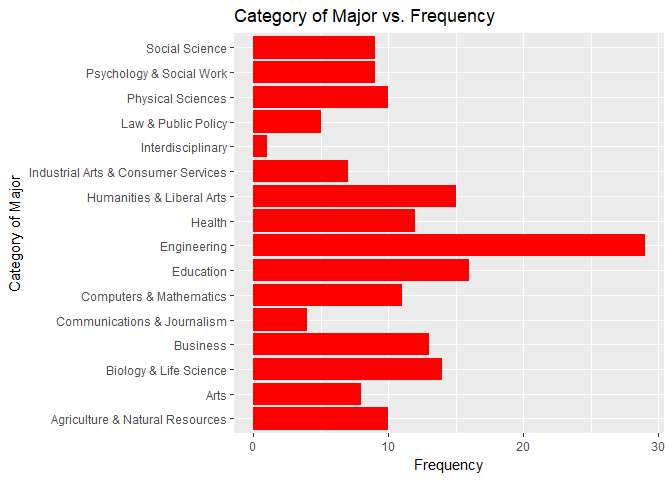

```r
library(ggplot2)

ggplot(major_count, aes(x=(Major_category), y=(freq))) +
  geom_bar(stat='identity', fill = 'red') +
  coord_flip() + labs(title ="Category of Major vs. Frequency", x = "Category of Major", y = "Frequency")
```

#### Write the fivethirtyeight data to a csv file.

Make sure that it does not have row labels.

```r
write.csv(major_count, "major_count.csv", row.names=F)
```